# Optimizing the Farm Store Gift Box Experience

Proposal Presentation

Digital Marketing Consultant

IBM 6540, Cal Poly Pomona

2026-07-07

# Introduction & Problem Statement

## The Current Friction Point

Using a classic storytelling framework, every hero encounters a roadblock. For our client’s online Farm Store, the obstacle isn’t the quality of the product—it is the digital ordering experience.

### The Status Quo

- Customers love physical, customizable gift boxes.
- The current web interface requires multiple steps to build a box.
- High bounce rates occur during the step-by-step selection process.

### The Complication

> **The Problem Statement:** While pre-made configurations sell reliably, the highly profitable “design-your-own” customizable gift box option suffers a **68% cart abandonment rate** due to user interface friction.

# Research Framework

## Analytics Objective & Importance

### Core Objective

Our primary analytics objective is to isolate exactly where users experience cognitive overload and abandon the customization funnel.

1. **Track Step-by-Step Drop-offs:** Quantify micro-abandonment rates at the box size, item insertion, and greeting card steps.
2. **Predict Order Completion:** Identify which item combinations or session lengths correlate with a completed sale.
3. **Formulate UX Interventions:** Redesign the interface layout based on predictive interaction data.

. . .

### Why This Matters Now

Optimizing this path turns casual web traffic into high-value revenue. Decreasing abandonment by just 15% recovers substantial lost margins for the Farm Store ahead of the peak holiday season.

## Literature Review & Data Adequacy

### Theoretical Foundation

Well-established consumer behavior frameworks, such as the **Technology Acceptance Model (TAM)** and the **Theory of Choice Overload**, suggest that when digital interfaces offer too many unguided choices, consumer purchase intent drops sharply.

### Data Assessment

- **Current Assets:** We have successfully gathered 3 months of granular Google Analytics 4 (GA4) clickstream events and Shopify session logs.
- **Adequacy:** This dataset is highly adequate for identifying drop-off stages.
- **Need for Additional Analysis?** Yes. While clickstream data tells us *where* users leave, we will require a post-purchase survey to understand *why* they preferred pre-made options over building their own.

See: Iyengar, S. S., & Lepper, M. R. (2000). “When choice is demotivating.” *Journal of Personality and Social Psychology*.

# Methodology & Data Visualization

## Data Wrangling & Sample Characteristics

```r
# 1. Simulate the Farm Store session data
set.seed(123)
session_data <- data.frame(
  Funnel_Stage = factor(c("1. View Customizer", "2. Select Box Size", "3. Add Items", "4. Checkout Completed"),
                        levels = c("1. View Customizer", "2. Select Box Size", "3. Add Items", "4. Checkout Completed")),
  Sessions = c(1200, 850, 410, 280)
)

# 2. Extract sample metric for inline narrative reporting
total_initial_users <- session_data$Sessions[1]
final_conversions <- session_data$Sessions[4]

# 3. Generate a reproducible visualization of the funnel
barplot(session_data$Sessions,
        names.arg = session_data$Funnel_Stage,
        col = "#8B4513",
        main = "Gift Box Customization Funnel Drop-off",
        ylab = "Number of Web Sessions",
        xlab = "User Journey Stage")
```

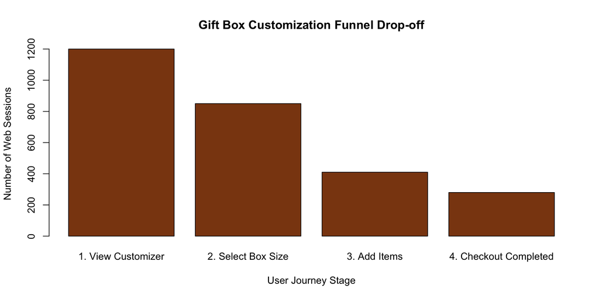

# Methodology Core

## Measures & Analytics Methods

### Variables and Operational Measures

- **Dependent Variable ($Y$):** Conversion Success (Binary: 1 if checkout completed, 0 if abandoned).
- **Independent Variables ($X$):**
  - *Time Spent per Stage (Continuous):* Measured in seconds via clickstream timestamps.
  - *Item Complexity (Discrete):* Total count of distinct items added to the virtual box.
  - *Device Type (Categorical):* Mobile vs. Desktop user-agent string.

### Analytics Strategy

To identify the predictive thresholds of drop-offs, we fit a binary logistic regression model:

$$\ln\left(\frac{P}{1-P}\right) = \beta_0 + \beta_1(\text{Time}) + \beta_2(\text{Item Count}) + \beta_3(\text{Mobile User})$$

This methodology identifies whether choice fatigue or device optimization challenges drive user abandonment.

# References

## References

- Davis, F. D. (1989). “Perceived usefulness, perceived ease of use, and user acceptance of information technology.” *MIS Quarterly*, 13(3), 319-340.
- Iyengar, S. S., & Lepper, M. R. (2000). “When choice is demotivating: Can one desire too much of a good thing?” *Journal of Personality and Social Psychology*, 79(6), 995-1006.
- Miller, D. (2017). *Building a StoryBrand: Clarify Your Message So Customers Will Listen.* HarperCollins Leadership.
- Quarto Documentation (2026). *Revealjs Presentations Authoring Guide.* Retrieved from https://quarto.org